# Predicting Words

Fabiano Peruzzo Schwartz  
April 27th, 2015

Data Science Specialization  
Capstone Project

[figure not shown]

### Initial points

- Natural Language Processing (NLP) involves natural language understanding, that is, enabling computers to derive meaning from human or natural language input.
- NLP is currently used in a wide range of applications such as information extraction, machine translation, sentiment analysis and question answering, among others.
- The present work consists on developing an NLP tool for predicting the next word given a sequence of words. The main goal is to correctly predict the next word.
- For this task, large textual data sets obtained from blogs, twitter and news were processed in order to build a training data set able to support good predictions.
- This initiative was thought in collaboration with [Coursera / Johns Hopkins University](https://www.coursera.org/course/dsscapstone) and [SwiftKey](http://swiftkey.com/en/).

### Training data set

- The training data set was constructed from a random sample of 20% of the original size of the raw data sets. After preprocessing, an *n*-gram model was built (*n* = 1 to 5)

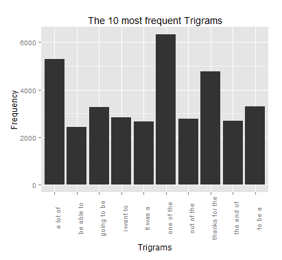

### *n*-gram model

- An *n*-gram is a contiguous sequence of *n* items from a given sequence of text.
- We can estimate the population probability *p<sub>i</sub>* of an *n*-gram from the sample frequency *r<sub>i</sub>* .
- If *N* is the number of distinct *n*-grams in the sample, an estimate for *p<sub>i</sub>* is *r<sub>i</sub>* /*N*.
- However, it computes zero for any unseen *n*-gram which is quantitatively inaccurate.

### Prediction algorithm

- For improving *p<sub>i</sub>* estimates, [Good-Turing](http://www.grsampson.net/AGtf1.html) frequency estimation techniques were used: an estimate for the total population frequency of all unseen *n*-grams is taken.
- The prediction for the next word of a sequence was based on the Backoff *n*-gram algorithm: if the *n*-gram we need has zero counts, we approximate it by backing off to the (*n*-1)-gram.
- For performance improvement: only *n*-grams with counts higher than 1 were kept; a unigram index was implemented and map each token to an integer.
- For example, the *3*-gram “thanks for the” is represented by

  | **UNIGRAM** |  | **TRIGRAM** |  |  |
  | --- | --- | --- | --- | --- |
  | id | token1 | token1 | token2 | token3 |
  | 314647 | thanks | 314647 | 314752 | 314759 |
  | 314752 | for |  |  |  |
  | 314759 | the |  |  |  |

### The Shiny App

- The [Shiny App](http://fpschwartz1.shinyapps.io/PredictingWord) was written so as to accept an *n*-gram and predicts the next word.
- If a a bad word is predicted, a last minute substitution for **“#@#%#”** is made. For checking accuracy, the user can deselect the **Profanity filter** checkbox (at his/her own risk).
- It is also possible to see which are the other most probable words (up to twenty) predicted by the model. Just keep the checkbox **View other possible words** selected.
- For testing accuracy, a suggestion is to download some *n*-grams from the [Corpus of Contemporary American English (COCA)](http://www.ngrams.info/). My tests showed about 70% correct.
- This application is still a prototype and uses elementary techniques, but it is good enough to show the power of NLP and how we can make things better by using this branch of knowledge.
- My thanks to Coursera, Johns Hopkins University, and SwiftKey by the opportunity of learning about the exciting world of NLP.